# Introduction

This notebook will document my efforts to investigate an interesting dataset from the Prosper peer-to-peer lending platform, and to then apply some machine learning classifiers. There are many questions one could ask of this data, but in this exercise I will focus on one question specifically: whether one can successfully predict which loans will default. Prosper loans pay pretty hefty interest rates to their creditors.

Other than loan status I will also investigate other variables like Borrower APR and Prosper rating which pay a significant role in predicting loan status.

This data set contains 113,937 loans with 81 variables on each loan, including loan amount, borrower rate (or interest rate), current loan status, borrower income, and many others. However, we are not expected to explore all of the variables in the dataset! We will focus our exploration on about 10-15 of them.

```python
import pandas as pd
import numpy as np
import seaborn as sns
import matplotlib.pyplot as plt
```

```python
df = pd.read_csv('Prosperdata.csv')
```

```python
pd.set_option("display.max_columns", len(df.columns))
```

```python
df.head()
```

|  | ListingKey | ListingNumber | ListingCreationDate | CreditGrade | Term | LoanStatus | ClosedDate | BorrowerAPR | BorrowerRate | LenderYield | EstimatedEffectiveYield | EstimatedLoss | EstimatedReturn | ProsperRating (numeric) | ProsperRating (Alpha) | ProsperScore | ListingCategory (numeric) | BorrowerState | Occupation | EmploymentStatus | EmploymentStatusDuration | IsBorrowerHomeowner | CurrentlyInGroup | GroupKey | DateCreditPulled | CreditScoreRangeLower | CreditScoreRangeUpper | FirstRecordedCreditLine | CurrentCreditLines | … |
| --- | --- | --- | --- | --- | --- | --- | --- | --- | --- | --- | --- | --- | --- | --- | --- | --- | --- | --- | --- | --- | --- | --- | --- | --- | --- | --- | --- | --- | --- | --- |
| 0 | 1021339766868145413AB3B | 193129 | 2007-08-26 19:09:29.263000000 | C | 36 | Completed | 2009-08-14 00:00:00 | 0.16516 | 0.1580 | 0.1380 | NaN | NaN | NaN | NaN | NaN | NaN | 0 | CO | Other | Self-employed | 2.0 | True | True | NaN | 2007-08-26 18:41:46.780000000 | 640.0 | 659.0 | 2001-10-11 00:00:00 | 5.0 | … |
| 1 | 10273602499503308B223C1 | 1209647 | 2014-02-27 08:28:07.900000000 | NaN | 36 | Current | NaN | 0.12016 | 0.0920 | 0.0820 | 0.07960 | 0.0249 | 0.05470 | 6.0 | A | 7.0 | 2 | CO | Professional | Employed | 44.0 | False | False | NaN | 2014-02-27 08:28:14 | 680.0 | 699.0 | 1996-03-18 00:00:00 | 14.0 | … |
| 2 | 0EE9337825851032864889A | 81716 | 2007-01-05 15:00:47.090000000 | HR | 36 | Completed | 2009-12-17 00:00:00 | 0.28269 | 0.2750 | 0.2400 | NaN | NaN | NaN | NaN | NaN | NaN | 0 | GA | Other | Not available | NaN | False | True | 783C3371218786870A73D20 | 2007-01-02 14:09:10.060000000 | 480.0 | 499.0 | 2002-07-27 00:00:00 | NaN | … |
| 3 | 0EF5356002482715299901A | 658116 | 2012-10-22 11:02:35.010000000 | NaN | 36 | Current | NaN | 0.12528 | 0.0974 | 0.0874 | 0.08490 | 0.0249 | 0.06000 | 6.0 | A | 9.0 | 16 | GA | Skilled Labor | Employed | 113.0 | True | False | NaN | 2012-10-22 11:02:32 | 800.0 | 819.0 | 1983-02-28 00:00:00 | 5.0 | … |
| 4 | 0F023589499656230C5E3E2 | 909464 | 2013-09-14 18:38:39.097000000 | NaN | 36 | Current | NaN | 0.24614 | 0.2085 | 0.1985 | 0.18316 | 0.0925 | 0.09066 | 3.0 | D | 4.0 | 2 | MN | Executive | Employed | 44.0 | True | False | NaN | 2013-09-14 18:38:44 | 680.0 | 699.0 | 2004-02-20 00:00:00 | 19.0 | … |

```python
df.PercentFunded.value_counts()
```

```
1.0000    113067
0.9998         5
0.7000         4
0.8087         4
0.7784         3
           ...
0.8167         1
0.7854         1
0.7903         1
0.7167         1
0.9575         1
Name: PercentFunded, Length: 719, dtype: int64
```

```python
df.info()
```

```
<class 'pandas.core.frame.DataFrame'>
RangeIndex: 113937 entries, 0 to 113936
Data columns (total 81 columns):
 #   Column                               Non-Null Count   Dtype
---  ------                               --------------   -----
 0   ListingKey                           113937 non-null  object
 1   ListingNumber                        113937 non-null  int64
 2   ListingCreationDate                  113937 non-null  object
 3   CreditGrade                          28953 non-null   object
 4   Term                                 113937 non-null  int64
 5   LoanStatus                           113937 non-null  object
 6   ClosedDate                           55089 non-null   object
 7   BorrowerAPR                          113912 non-null  float64
 8   BorrowerRate                         113937 non-null  float64
 9   LenderYield                          113937 non-null  float64
```

[output cut: 73 more lines]

```python
df.describe()
```

|  | ListingNumber | Term | BorrowerAPR | BorrowerRate | LenderYield | EstimatedEffectiveYield | EstimatedLoss | EstimatedReturn | ProsperRating (numeric) | ProsperScore | ListingCategory (numeric) | EmploymentStatusDuration | CreditScoreRangeLower | CreditScoreRangeUpper | CurrentCreditLines | OpenCreditLines | TotalCreditLinespast7years | OpenRevolvingAccounts | OpenRevolvingMonthlyPayment | InquiriesLast6Months | TotalInquiries | CurrentDelinquencies | AmountDelinquent | DelinquenciesLast7Years | PublicRecordsLast10Years | PublicRecordsLast12Months | RevolvingCreditBalance | BankcardUtilization | AvailableBankcardCredit | … |
| --- | --- | --- | --- | --- | --- | --- | --- | --- | --- | --- | --- | --- | --- | --- | --- | --- | --- | --- | --- | --- | --- | --- | --- | --- | --- | --- | --- | --- | --- | --- |
| count | 1.139370e+05 | 113937.000000 | 113912.000000 | 113937.000000 | 113937.000000 | 84853.000000 | 84853.000000 | 84853.000000 | 84853.000000 | 84853.000000 | 113937.000000 | 106312.000000 | 113346.000000 | 113346.000000 | 106333.000000 | 106333.000000 | 113240.000000 | 113937.00000 | 113937.000000 | 113240.000000 | 112778.000000 | 113240.000000 | 106315.000000 | 112947.000000 | 113240.000000 | 106333.000000 | 1.063330e+05 | 106333.000000 | 106393.000000 | … |
| mean | 6.278857e+05 | 40.830248 | 0.218828 | 0.192764 | 0.182701 | 0.168661 | 0.080306 | 0.096068 | 4.072243 | 5.950067 | 2.774209 | 96.071582 | 685.567731 | 704.567731 | 10.317192 | 9.260164 | 26.754539 | 6.96979 | 398.292161 | 1.435085 | 5.584405 | 0.592052 | 984.507059 | 4.154984 | 0.312646 | 0.015094 | 1.759871e+04 | 0.561309 | 11210.225447 | … |
| std | 3.280762e+05 | 10.436212 | 0.080364 | 0.074818 | 0.074516 | 0.068467 | 0.046764 | 0.030403 | 1.673227 | 2.376501 | 3.996797 | 94.480605 | 66.458275 | 66.458275 | 5.457866 | 5.022644 | 13.637871 | 4.63097 | 447.159711 | 2.437507 | 6.429946 | 1.978707 | 7158.270157 | 10.160216 | 0.727868 | 0.154092 | 3.293640e+04 | 0.317918 | 19818.361309 | … |
| min | 4.000000e+00 | 12.000000 | 0.006530 | 0.000000 | -0.010000 | -0.182700 | 0.004900 | -0.182700 | 1.000000 | 1.000000 | 0.000000 | 0.000000 | 0.000000 | 19.000000 | 0.000000 | 0.000000 | 2.000000 | 0.00000 | 0.000000 | 0.000000 | 0.000000 | 0.000000 | 0.000000 | 0.000000 | 0.000000 | 0.000000 | 0.000000e+00 | 0.000000 | 0.000000 | … |
| 25% | 4.009190e+05 | 36.000000 | 0.156290 | 0.134000 | 0.124200 | 0.115670 | 0.042400 | 0.074080 | 3.000000 | 4.000000 | 1.000000 | 26.000000 | 660.000000 | 679.000000 | 7.000000 | 6.000000 | 17.000000 | 4.00000 | 114.000000 | 0.000000 | 2.000000 | 0.000000 | 0.000000 | 0.000000 | 0.000000 | 0.000000 | 3.121000e+03 | 0.310000 | 880.000000 | … |
| 50% | 6.005540e+05 | 36.000000 | 0.209760 | 0.184000 | 0.173000 | 0.161500 | 0.072400 | 0.091700 | 4.000000 | 6.000000 | 1.000000 | 67.000000 | 680.000000 | 699.000000 | 10.000000 | 9.000000 | 25.000000 | 6.00000 | 271.000000 | 1.000000 | 4.000000 | 0.000000 | 0.000000 | 0.000000 | 0.000000 | 0.000000 | 8.549000e+03 | 0.600000 | 4100.000000 | … |
| 75% | 8.926340e+05 | 36.000000 | 0.283810 | 0.250000 | 0.240000 | 0.224300 | 0.112000 | 0.116600 | 5.000000 | 8.000000 | 3.000000 | 137.000000 | 720.000000 | 739.000000 | 13.000000 | 12.000000 | 35.000000 | 9.00000 | 525.000000 | 2.000000 | 7.000000 | 0.000000 | 0.000000 | 3.000000 | 0.000000 | 0.000000 | 1.952100e+04 | 0.840000 | 13180.000000 | … |
| max | 1.255725e+06 | 60.000000 | 0.512290 | 0.497500 | 0.492500 | 0.319900 | 0.366000 | 0.283700 | 7.000000 | 11.000000 | 20.000000 | 755.000000 | 880.000000 | 899.000000 | 59.000000 | 54.000000 | 136.000000 | 51.00000 | 14985.000000 | 105.000000 | 379.000000 | 83.000000 | 463881.000000 | 99.000000 | 38.000000 | 20.000000 | 1.435667e+06 | 5.950000 | 646285.000000 | … |

# DataWrangling:

Taking a quick look at the data, there are a few potential processing tasks that jump out right away.

1) Some variables have a lot of null values. TotalProsperLoans, for instance, and a lot of other variables associated with the Prosper history of the debtor.

2) A lot of these variables seem to be administrative identifiers (e.g. ListingKey and ListingNumber), and redundant ones at that. They won't be of much use to us.

```python
df.isna().sum().sort_values(ascending=False) # counting missing data
```

```
GroupKey                               100596
LoanFirstDefaultedCycleNumber           96985
ScorexChangeAtTimeOfListing             95009
ProsperPaymentsLessThanOneMonthLate     91852
ProsperPaymentsOneMonthPlusLate         91852
                                        ...
StatedMonthlyIncome                         0
IncomeVerifiable                            0
IncomeRange                                 0
InvestmentFromFriendsAmount                 0
ListingKey                                  0
Length: 81, dtype: int64
```

As there are too many columns in the dataframe it is difficult to understand , but vaguely we can say that there are around 12 column of which more that 50% data is null . so will ignore these columns. In further investigation we will observe them individually.

```python
pd.set_option("display.max_columns", len(df.columns))
```

```python
df.head()
```

|  | ListingKey | ListingNumber | ListingCreationDate | CreditGrade | Term | LoanStatus | ClosedDate | BorrowerAPR | BorrowerRate | LenderYield | EstimatedEffectiveYield | EstimatedLoss | EstimatedReturn | ProsperRating (numeric) | ProsperRating (Alpha) | ProsperScore | ListingCategory (numeric) | BorrowerState | Occupation | EmploymentStatus | EmploymentStatusDuration | IsBorrowerHomeowner | CurrentlyInGroup | GroupKey | DateCreditPulled | CreditScoreRangeLower | CreditScoreRangeUpper | FirstRecordedCreditLine | CurrentCreditLines | … |
| --- | --- | --- | --- | --- | --- | --- | --- | --- | --- | --- | --- | --- | --- | --- | --- | --- | --- | --- | --- | --- | --- | --- | --- | --- | --- | --- | --- | --- | --- | --- |
| 0 | 1021339766868145413AB3B | 193129 | 2007-08-26 19:09:29.263000000 | C | 36 | Completed | 2009-08-14 00:00:00 | 0.16516 | 0.1580 | 0.1380 | NaN | NaN | NaN | NaN | NaN | NaN | 0 | CO | Other | Self-employed | 2.0 | True | True | NaN | 2007-08-26 18:41:46.780000000 | 640.0 | 659.0 | 2001-10-11 00:00:00 | 5.0 | … |
| 1 | 10273602499503308B223C1 | 1209647 | 2014-02-27 08:28:07.900000000 | NaN | 36 | Current | NaN | 0.12016 | 0.0920 | 0.0820 | 0.07960 | 0.0249 | 0.05470 | 6.0 | A | 7.0 | 2 | CO | Professional | Employed | 44.0 | False | False | NaN | 2014-02-27 08:28:14 | 680.0 | 699.0 | 1996-03-18 00:00:00 | 14.0 | … |
| 2 | 0EE9337825851032864889A | 81716 | 2007-01-05 15:00:47.090000000 | HR | 36 | Completed | 2009-12-17 00:00:00 | 0.28269 | 0.2750 | 0.2400 | NaN | NaN | NaN | NaN | NaN | NaN | 0 | GA | Other | Not available | NaN | False | True | 783C3371218786870A73D20 | 2007-01-02 14:09:10.060000000 | 480.0 | 499.0 | 2002-07-27 00:00:00 | NaN | … |
| 3 | 0EF5356002482715299901A | 658116 | 2012-10-22 11:02:35.010000000 | NaN | 36 | Current | NaN | 0.12528 | 0.0974 | 0.0874 | 0.08490 | 0.0249 | 0.06000 | 6.0 | A | 9.0 | 16 | GA | Skilled Labor | Employed | 113.0 | True | False | NaN | 2012-10-22 11:02:32 | 800.0 | 819.0 | 1983-02-28 00:00:00 | 5.0 | … |
| 4 | 0F023589499656230C5E3E2 | 909464 | 2013-09-14 18:38:39.097000000 | NaN | 36 | Current | NaN | 0.24614 | 0.2085 | 0.1985 | 0.18316 | 0.0925 | 0.09066 | 3.0 | D | 4.0 | 2 | MN | Executive | Employed | 44.0 | True | False | NaN | 2013-09-14 18:38:44 | 680.0 | 699.0 | 2004-02-20 00:00:00 | 19.0 | … |

Next, about 20 loans are missing an APR value. Because APR is equal to the borrower rate + fees, let's calculate the median difference between the two, and add that value to the borrower rate of our data points missing an APR.

```python
borrower_fees = df["BorrowerAPR"] - df["BorrowerRate"]
borrower_fees.median()
```

```
0.025019999999999987
```

```python
df['Recommendations'].value_counts()
```

```
0     109678
1       3516
2        568
3        108
4         26
5         14
9          6
7          5
6          4
8          3
16         2
18         2
24         1
14         1
19         1
21         1
39         1
Name: Recommendations, dtype: int64
```

```python
df["BorrowerAPR"].fillna(df["BorrowerRate"] + borrower_fees.median(), inplace=True)

df["BorrowerAPR"].isnull().sum()
```

```
0
```

EstimatedEffectiveYield will always be the borrower rate minus some expected loss from interest charge-offs and fees.

```python
estimated_loss_from_fees = df["BorrowerRate"] - df["EstimatedEffectiveYield"]
estimated_loss_from_fees.median()
```

```
0.01915
```

```python
df["EstimatedEffectiveYield"].fillna(df["BorrowerRate"] - estimated_loss_from_fees.median(), inplace=True)

df["EstimatedEffectiveYield"].isnull().sum()
```

```
0
```

```python
df["EstimatedLoss"].fillna(df["EstimatedLoss"].median(), inplace=True)

df["EstimatedLoss"].isnull().sum()
```

```
0
```

The numeric ProsperRating and the ProsperScore NaNs can both be replaced with median values.

```python
df["ProsperRating (numeric)"].fillna(df["ProsperRating (numeric)"].median(), inplace=True)
df["ProsperScore"].fillna(df["ProsperScore"].median(), inplace=True)


df["ProsperRating (numeric)"].isnull().sum(), df["ProsperScore"].isnull().sum()
```

```
(0, 0)
```

There are a host of variables which hold a lot of promise for our eventual classification algorithm, and are only missing a relatively small number of values. I'm going to drop all the rows missing values for these, rather than filling them out with arbitrary median values or 0s.

```python
df.dropna(subset=["EmploymentStatusDuration", "CreditScoreRangeLower", "FirstRecordedCreditLine", "CurrentCreditLines",
                  "TotalCreditLinespast7years"], inplace=True)
```

```python
df.info()
```

```
<class 'pandas.core.frame.DataFrame'>
Int64Index: 106290 entries, 0 to 113936
Data columns (total 81 columns):
 #   Column                               Non-Null Count   Dtype
---  ------                               --------------   -----
 0   ListingKey                           106290 non-null  object
 1   ListingNumber                        106290 non-null  int64
 2   ListingCreationDate                  106290 non-null  object
 3   CreditGrade                          21325 non-null   object
 4   Term                                 106290 non-null  int64
 5   LoanStatus                           106290 non-null  object
 6   ClosedDate                           47452 non-null   object
 7   BorrowerAPR                          106290 non-null  float64
 8   BorrowerRate                         106290 non-null  float64
 9   LenderYield                          106290 non-null  float64
```

[output cut: 73 more lines]

1) DebtToIncomeRatio, which strikes me as a potentially very useful feature. Let's take a look at what's going on there and do our best to reconstruct or substitute the missing values.

```python
df_debt_income_null = df[df["DebtToIncomeRatio"].isnull()]

df_debt_income_null[:5]
```

|  | ListingKey | ListingNumber | ListingCreationDate | CreditGrade | Term | LoanStatus | ClosedDate | BorrowerAPR | BorrowerRate | LenderYield | EstimatedEffectiveYield | EstimatedLoss | EstimatedReturn | ProsperRating (numeric) | ProsperRating (Alpha) | ProsperScore | ListingCategory (numeric) | BorrowerState | Occupation | EmploymentStatus | EmploymentStatusDuration | IsBorrowerHomeowner | CurrentlyInGroup | GroupKey | DateCreditPulled | CreditScoreRangeLower | CreditScoreRangeUpper | FirstRecordedCreditLine | CurrentCreditLines | … |
| --- | --- | --- | --- | --- | --- | --- | --- | --- | --- | --- | --- | --- | --- | --- | --- | --- | --- | --- | --- | --- | --- | --- | --- | --- | --- | --- | --- | --- | --- | --- |
| 40 | 10A43601079743929992413 | 1167746 | 2014-01-27 12:02:57.523000000 | NaN | 60 | Current | NaN | 0.19630 | 0.1725 | 0.1625 | 0.15163 | 0.0724 | 0.07923 | 4.0 | C | 4.0 | 1 | WA | Other | Self-employed | 276.0 | False | False | NaN | 2014-01-25 10:47:25 | 680.0 | 699.0 | 1985-12-20 00:00:00 | 10.0 | … |
| 69 | 0F37360159310530849DA23 | 1162592 | 2014-01-25 12:07:54.537000000 | NaN | 60 | Current | NaN | 0.13636 | 0.1139 | 0.1039 | 0.09989 | 0.0349 | 0.06499 | 6.0 | A | 11.0 | 1 | IL | Investor | Self-employed | 12.0 | True | True | NaN | 2014-01-25 11:51:41 | 700.0 | 719.0 | 1995-08-01 00:00:00 | 5.0 | … |
| 78 | 0DFE3425061927556BB8A75 | 359657 | 2008-06-29 23:23:40.157000000 | A | 36 | Chargedoff | 2009-04-09 00:00:00 | 0.18454 | 0.1700 | 0.1600 | 0.15085 | 0.0724 | NaN | 4.0 | NaN | 6.0 | 3 | CA | Realtor | Full-time | 68.0 | True | False | NaN | 2008-06-29 23:13:04.860000000 | 720.0 | 739.0 | 1995-11-29 00:00:00 | 14.0 | … |
| 100 | 0F67356860455769574096F | 704916 | 2013-01-25 11:48:26.040000000 | NaN | 36 | Chargedoff | 2013-08-30 00:00:00 | 0.35356 | 0.3134 | 0.3034 | 0.27600 | 0.1575 | 0.11850 | 1.0 | HR | 3.0 | 13 | CA | Other | Not employed | 12.0 | False | False | NaN | 2013-01-11 12:10:13 | 720.0 | 739.0 | 2000-09-10 00:00:00 | 3.0 | … |
| 103 | 0F843543787869030F017F8 | 579737 | 2012-04-17 11:58:52.270000000 | NaN | 36 | Chargedoff | 2013-03-22 00:00:00 | 0.26681 | 0.2287 | 0.2187 | 0.21340 | 0.0990 | 0.11440 | 3.0 | D | 2.0 | 3 | CO | Truck Driver | Self-employed | 29.0 | True | False | NaN | 2012-04-17 11:58:46 | 680.0 | 699.0 | 1993-10-26 00:00:00 | 9.0 | … |

```python
#Calculate DebtToIncomeRatio for unverifiable incomes, adding $1 to account for $0/month incomes
df["DebtToIncomeRatio"].fillna(df["MonthlyLoanPayment"] / (df["StatedMonthlyIncome"] + 1), inplace = True)

df["DebtToIncomeRatio"].isnull().sum()
```

```
0
```

We will drop te unneccessary columns.

```python
df.drop("ScorexChangeAtTimeOfListing", axis=1, inplace=True)
```

```python
df.drop(["ListingKey", "ListingNumber", "LoanKey", "LoanNumber"], axis=1, inplace=True)
```

```python
df[['ListingCreationDate' ,'ClosedDate' ,'LoanOriginationDate']] = df[['ListingCreationDate' ,'ClosedDate' ,'LoanOriginationDate']].astype('datetime64[ns]')
```

```python
df['ListingCreationDate'].apply(lambda x: x.strftime('%Y-%m')).value_counts().sort_index()
```

```
2007-02     684
2007-03    1127
2007-04    1032
2007-05    1061
2007-06     954
           ...
2013-11    4541
2013-12    5127
2014-01    5603
2014-02    4248
2014-03     883
Name: ListingCreationDate, Length: 80, dtype: int64
```

```python
df["LoanOriginatedMonth"] = df['LoanOriginationDate'].map(lambda x: x.month)
```

```python
df["LoanOriginatedMonth"] = df['LoanOriginationDate'].map(lambda x: x.month)
df["LoanOriginatedYear"] = df['LoanOriginationDate'].map(lambda x: x.year)
```

```python
df["ClosingMonth"] = df['ClosedDate'].map(lambda x: x.month)
df["ClosingYear"] = df['ClosedDate'].map(lambda x: x.year)
df.info()
```

```
<class 'pandas.core.frame.DataFrame'>
Int64Index: 106290 entries, 0 to 113936
Data columns (total 80 columns):
 #   Column                               Non-Null Count   Dtype
---  ------                               --------------   -----
 0   ListingCreationDate                  106290 non-null  datetime64[ns]
 1   CreditGrade                          21325 non-null   object
 2   Term                                 106290 non-null  int64
 3   LoanStatus                           106290 non-null  object
 4   ClosedDate                           47452 non-null   datetime64[ns]
 5   BorrowerAPR                          106290 non-null  float64
 6   BorrowerRate                         106290 non-null  float64
 7   LenderYield                          106290 non-null  float64
 8   EstimatedEffectiveYield              106290 non-null  float64
 9   EstimatedLoss                        106290 non-null  float64
```

[output cut: 72 more lines]

```python
df["LoanOriginalAmount"].describe()
```

```
count    106290.000000
mean       8567.463929
std        6266.515570
min        1000.000000
25%        4000.000000
50%        7000.000000
75%       12000.000000
max       35000.000000
Name: LoanOriginalAmount, dtype: float64
```

# Univariate Exploration Of data :

## LoanOriginalAmount Destribution

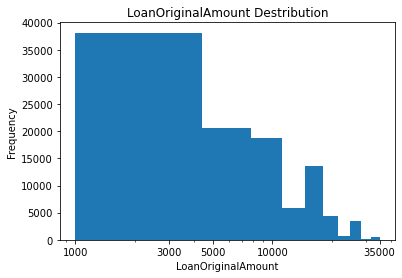

```python
bin_edges = np.arange(0, df['LoanOriginalAmount'].max()+1, 1)
plt.xscale('log')
tick_locs = [1000, 3000,5000,10000,35000]
plt.xticks(tick_locs, tick_locs)
plt.title('LoanOriginalAmount Destribution')
plt.xlabel('LoanOriginalAmount')
plt.ylabel('Frequency')
plt.hist(data = df, x = 'LoanOriginalAmount')
```

## Borrower Rate Destribution

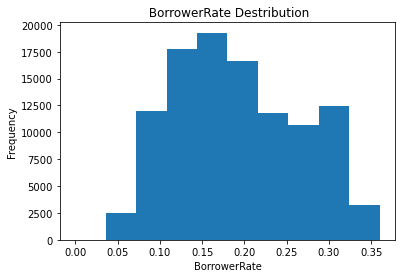

```python
bin_edges = np.arange(0, df['BorrowerRate'].max()+1, 1)
plt.hist(data = df, x = 'BorrowerRate')
plt.title(' BorrowerRate Destribution')
plt.xlabel('BorrowerRate')
plt.ylabel('Frequency')
```

Above plot is skewed towards the right direction.Highest number of borrower rate recorded was between 0.5 and 0.2

## Borrower APR

The BorrowerRate (interest rate) refers to the annual cost of a loan to a borrower and is expressed as a percentage. The interest rate does not include fees charged for the loan. The BorrowerAPR is the annual cost of a loan to a borrower. Unlike an interest rate, it includes other charges or fees (such as mortgage insurance, most closing costs, discount points and loan origination fees) to reflect the total cost of the loan.

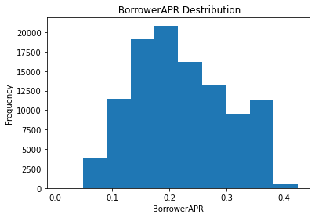

```python
bin_edges = np.arange(0, df['BorrowerAPR'].max()+1, 1)
plt.hist(data = df, x = 'BorrowerAPR')
plt.title(' BorrowerAPR Destribution')
plt.xlabel('BorrowerAPR')
plt.ylabel('Frequency')
```

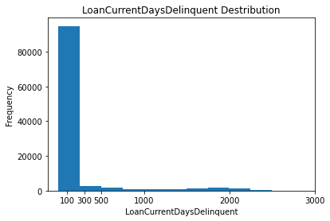

```python
bin_edges = np.arange(0, df['LoanCurrentDaysDelinquent'].max())
plt.hist(data = df, x = 'LoanCurrentDaysDelinquent')
tick_locs = [100,300,500,1000,2000,3000]
plt.xticks(tick_locs, tick_locs)
plt.title('LoanCurrentDaysDelinquent Destribution')
plt.xlabel('LoanCurrentDaysDelinquent')
plt.ylabel('Frequency')
```

## Occupation Destribution:

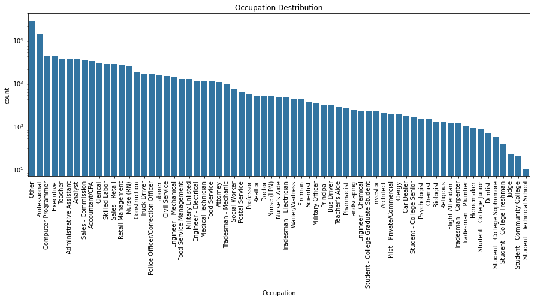

```python
base_color = sns.color_palette()[0]
cat_order = df['Occupation'].value_counts().index
plt.figure(figsize=(15,5))
g=sns.countplot(data = df, x = 'Occupation', color = base_color, order = cat_order)
g.set_yscale("log")
plt.xticks(rotation = 90)
plt.title('Occupation Destribution')
```

If we observe the above plot ComputerProgrammer,Excecutives and Teacher have the largest count other than proffesional and Others.But these two does'nt provide useful information.

```
(2000.0, 6000.0)
```

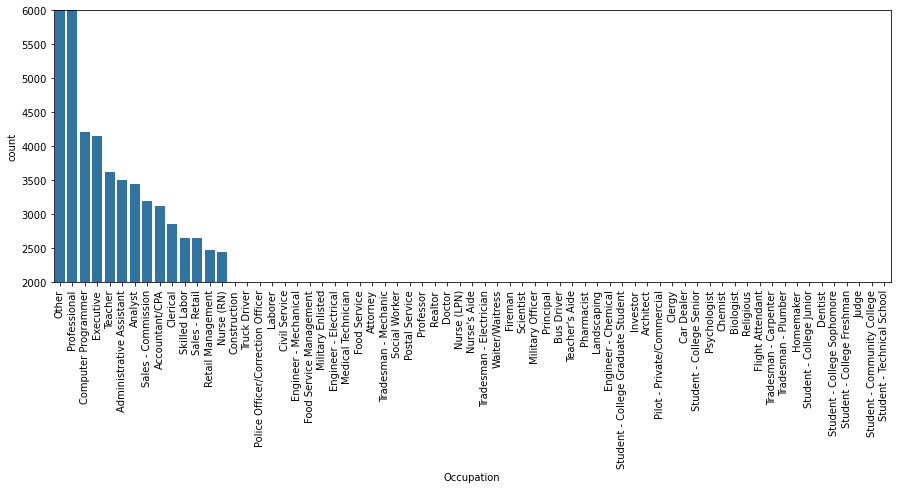

```python
base_color = sns.color_palette()[0]
cat_order = df['Occupation'].value_counts().index
plt.figure(figsize=(15,5))
sns.countplot(data = df, x = 'Occupation', color = base_color, order = cat_order)
plt.xticks(rotation = 90)
plt.ylim(2000,6000)
```

## EmploymentStatus Destribution:

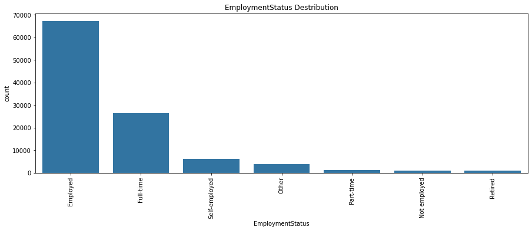

```python
base_color = sns.color_palette()[0]
cat_order = df['EmploymentStatus'].value_counts().index
plt.figure(figsize=(15,5))
sns.countplot(data = df, x = 'EmploymentStatus', color = base_color, order = cat_order)
plt.xticks(rotation = 90)
plt.title('EmploymentStatus Destribution')
```

From the above plots highest number of borrowers counted were Employed followed by Full time employers while retired , Part-time , other and not employed have least count.

## Investors Destribution:

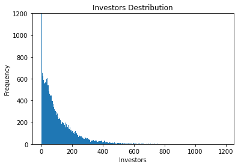

```python
bin_edges = np.arange(0, df['Investors'].max()+1, 1)
plt.hist(data = df, x = 'Investors', bins = bin_edges)
plt.ylim(0,1200)
plt.title('Investors Destribution')
plt.xlabel('Investors')
plt.ylabel('Frequency')
```

```python
df.Investors.describe()
```

```
count    106290.000000
mean         81.410904
std         104.881307
min           1.000000
25%           1.000000
50%          44.000000
75%         118.000000
max        1189.000000
Name: Investors, dtype: float64
```

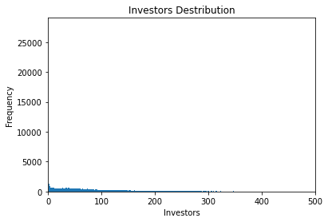

```python
bin_edges = np.arange(0, df['Investors'].max()+1, 1)
plt.hist(data = df, x = 'Investors', bins = bin_edges)
plt.xlim(0,500)
plt.title('Investors Destribution')
plt.xlabel('Investors')
plt.ylabel('Frequency')
```

```python
df.Investors.value_counts()
```

```
1      27668
2       1288
3        930
4        764
5        686
       ...
592        1
692        1
655        1
782        1
831        1
Name: Investors, Length: 749, dtype: int64
```

```
(0.0, 200.0)
```

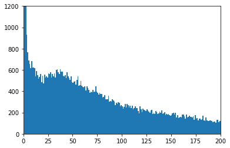

```python
bin_edges = np.arange(0, df['Investors'].max()+1, 1)
plt.hist(data = df, x = 'Investors', bins = bin_edges)
plt.ylim(0,1200)
plt.xlim(0,200)
```

## Monthly Loan payment Destribution:

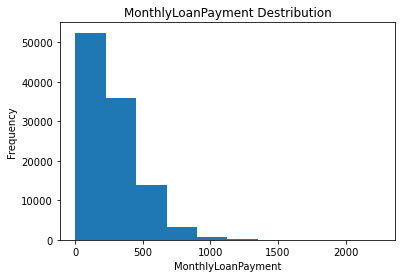

```python
plt.hist(data = df, x = 'MonthlyLoanPayment')
plt.title('MonthlyLoanPayment Destribution')
plt.xlabel('MonthlyLoanPayment')
plt.ylabel('Frequency')
```

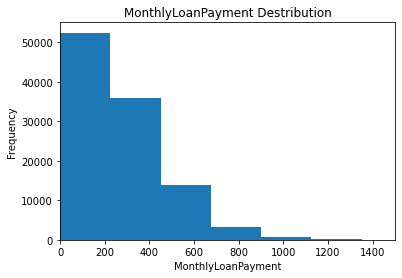

```python
plt.hist(data = df, x = 'MonthlyLoanPayment')
plt.xlim(0,1500)
plt.title('MonthlyLoanPayment Destribution')
plt.xlabel('MonthlyLoanPayment')
plt.ylabel('Frequency')
```

## Term of loan Destribution:

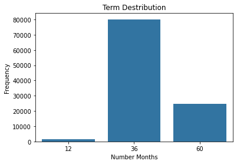

```python
sns.countplot(data = df, x = 'Term', color = base_color)
plt.title('Term Destribution')
plt.xlabel('Number Months')
plt.ylabel('Frequency')
```

From above destribution we observe most of the borrowers opted for 36 of loan term while minimal number of borrowers opted for 12 month of loan term.

## ListingCategory Destribution

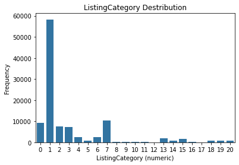

```python
sns.countplot(data = df, x = 'ListingCategory (numeric)', color = base_color)
plt.title('ListingCategory Destribution')
plt.xlabel('ListingCategory (numeric)')
plt.ylabel('Frequency')
```

```python
df['ListingCategory (numeric)']
```

```
0          0
1          2
3         16
4          2
5          1
          ..
113932     1
113933     7
113934     1
113935     2
113936     1
Name: ListingCategory (numeric), Length: 106290, dtype: int64
```

```python
df.IncomeRange.value_counts()
```

```
$25,000-49,999    32177
$50,000-74,999    31043
$100,000+         17333
$75,000-99,999    16914
$1-24,999          7265
Not employed        802
$0                  618
Not displayed       138
Name: IncomeRange, dtype: int64
```

## IncomeRange Destribution

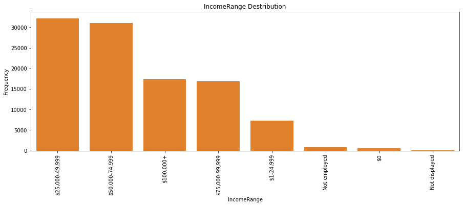

```python
base_color = sns.color_palette()[1]
cat_order = df['IncomeRange'].value_counts().index
plt.figure(figsize=(15,5))
sns.countplot(data = df, x = 'IncomeRange', color = base_color, order = cat_order)
plt.xticks(rotation = 90)
plt.title('IncomeRange Destribution')
plt.xlabel('IncomeRange')
plt.ylabel('Frequency')
```

```python
df.info()
```

```
<class 'pandas.core.frame.DataFrame'>
Int64Index: 106290 entries, 0 to 113936
Data columns (total 80 columns):
 #   Column                               Non-Null Count   Dtype
---  ------                               --------------   -----
 0   ListingCreationDate                  106290 non-null  datetime64[ns]
 1   CreditGrade                          21325 non-null   object
 2   Term                                 106290 non-null  int64
 3   LoanStatus                           106290 non-null  object
 4   ClosedDate                           47452 non-null   datetime64[ns]
 5   BorrowerAPR                          106290 non-null  float64
 6   BorrowerRate                         106290 non-null  float64
 7   LenderYield                          106290 non-null  float64
 8   EstimatedEffectiveYield              106290 non-null  float64
 9   EstimatedLoss                        106290 non-null  float64
```

[output cut: 72 more lines]

```python
df.DebtToIncomeRatio.describe()
```

```
count    106290.000000
mean          3.136279
std          34.174073
min           0.000000
25%           0.138948
50%           0.210000
75%           0.320000
max        1130.900000
Name: DebtToIncomeRatio, dtype: float64
```

```python
df.rename(columns={'ProsperRating (Alpha)':'ProsperRatingAlpha'},
                 inplace=True)
```

```python
df.ProsperRatingAlpha.value_counts()
```

```
C     18340
B     15579
A     14549
D     14268
E      9795
HR     6932
AA     5371
Name: ProsperRatingAlpha, dtype: int64
```

## Prosper Score Distribution:

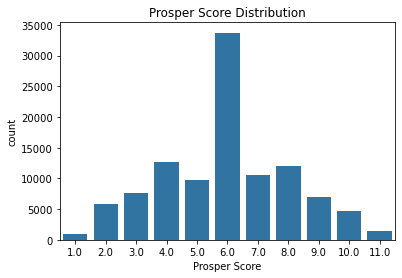

```python
#Prosper Score Distribution
base_color = sns.color_palette()[0]
sns.countplot(data=df,x= 'ProsperScore',color=base_color)
plt.title('Prosper Score Distribution')
plt.xlabel('Prosper Score');
```

Highest number of Prosper Score Reported was 6.0 while least prosper rating counted was 1.0 and 11.0.

## ProsperRatingAlpha Distribution:

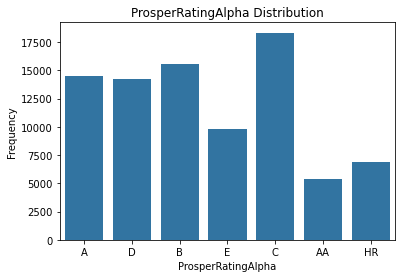

```python
base_color = sns.color_palette()[0]
sns.countplot(data=df,x= 'ProsperRatingAlpha',color=base_color)
plt.title('ProsperRatingAlpha Distribution')
plt.xlabel('ProsperRatingAlpha')
plt.ylabel('Frequency')
```

From the above destribution it is clear that highest number of borrowers belong to prosper rating C,and lowest number of borrowers belong to prosper rating AA.

## Borrower State Destribution:

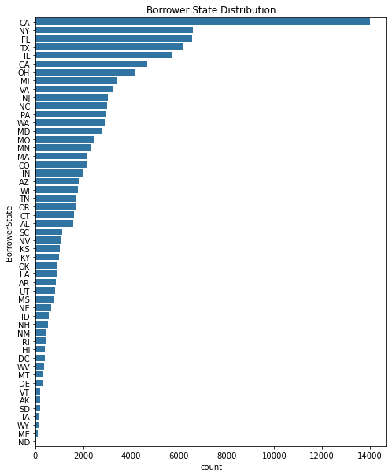

```python
#Borrower State Distrobution
cat_order = df.BorrowerState.value_counts().index
plt.figure(figsize=[8, 10])
sns.countplot(data=df,y='BorrowerState',color=base_color, order=cat_order);
plt.title('Borrower State Distribution');
```

Highest number of borrowers reported were from the state CA(California),NY(NewYork) and Fl(Florida) and least number of borrowers were reported in ND(North Dakota).

```python
df['DebtToIncomeRatio'].describe()
df.info()
```

```
<class 'pandas.core.frame.DataFrame'>
Int64Index: 106290 entries, 0 to 113936
Data columns (total 80 columns):
 #   Column                               Non-Null Count   Dtype
---  ------                               --------------   -----
 0   ListingCreationDate                  106290 non-null  datetime64[ns]
 1   CreditGrade                          21325 non-null   object
 2   Term                                 106290 non-null  int64
 3   LoanStatus                           106290 non-null  object
 4   ClosedDate                           47452 non-null   datetime64[ns]
 5   BorrowerAPR                          106290 non-null  float64
 6   BorrowerRate                         106290 non-null  float64
 7   LenderYield                          106290 non-null  float64
 8   EstimatedEffectiveYield              106290 non-null  float64
 9   EstimatedLoss                        106290 non-null  float64
```

[output cut: 72 more lines]

## Loan Originated Year destribution:

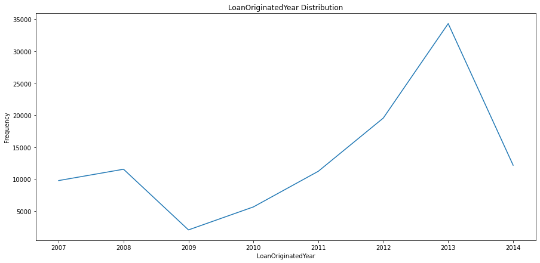

```python
fig, ax = plt.subplots(figsize=(15,7))
df.groupby(['LoanOriginatedYear']).count()['ListingCreationDate'].plot(ax = ax)
plt.title('LoanOriginatedYear Distribution')
plt.xlabel('LoanOriginatedYear')
plt.ylabel('Frequency')
```

We can clearly oberve that highest number of loan Originated in year 2013.Lowest number of loan was originated in the year 2009.

## Loan Status Destribution throughout the given years:

```python
fig, ax = plt.subplots(figsize=(15,7))
df.groupby(['LoanOriginatedYear','LoanStatus']).count()['LoanOriginalAmount'].unstack().plot(ax=ax)
plt.title('LoanOriginatedYear and Loan status Distribution')
plt.xlabel('LoanOriginatedYear')
plt.ylabel('Loan Status')
```

[output not shown]

[output not shown]

```python
df.info()
```

```
<class 'pandas.core.frame.DataFrame'>
Int64Index: 106290 entries, 0 to 113936
Data columns (total 80 columns):
 #   Column                               Non-Null Count   Dtype
---  ------                               --------------   -----
 0   ListingCreationDate                  106290 non-null  datetime64[ns]
 1   CreditGrade                          21325 non-null   object
 2   Term                                 106290 non-null  int64
 3   LoanStatus                           106290 non-null  object
 4   ClosedDate                           47452 non-null   datetime64[ns]
 5   BorrowerAPR                          106290 non-null  float64
 6   BorrowerRate                         106290 non-null  float64
 7   LenderYield                          106290 non-null  float64
 8   EstimatedEffectiveYield              106290 non-null  float64
 9   EstimatedLoss                        106290 non-null  float64
```

[output cut: 72 more lines]

```python
df.LoanOriginalAmount.describe()
```

```
count    106290.000000
mean       8567.463929
std        6266.515570
min        1000.000000
25%        4000.000000
50%        7000.000000
75%       12000.000000
max       35000.000000
Name: LoanOriginalAmount, dtype: float64
```

```python
df.LoanStatus.value_counts()
```

```
Current                   56566
Completed                 33530
Chargedoff                10632
Defaulted                  3289
Past Due (1-15 days)        806
Past Due (31-60 days)       363
Past Due (61-90 days)       313
Past Due (91-120 days)      304
Past Due (16-30 days)       265
FinalPaymentInProgress      205
Past Due (>120 days)         16
Cancelled                     1
Name: LoanStatus, dtype: int64
```

In loan status column we need to focus on the values which gives us information about if loanstatus is complecated or defaulted.Because there is no way to tell whether "current" loans will eventually default or not.We cant use them for our analysis.In order to simplify our analysis Lets assume all the "past due" and "chargeoff" loans(and that one cancellation) will default.Thus we will be left with two classes: "completed" and "defaulted". Let's encode those binary outcomes as 1 and 0, respectively.

```python
df_ls = df[df["LoanStatus"] != "Current"]

df_ls["LoanStatus"].value_counts()
```

```
Completed                 33530
Chargedoff                10632
Defaulted                  3289
Past Due (1-15 days)        806
Past Due (31-60 days)       363
Past Due (61-90 days)       313
Past Due (91-120 days)      304
Past Due (16-30 days)       265
FinalPaymentInProgress      205
Past Due (>120 days)         16
Cancelled                     1
Name: LoanStatus, dtype: int64
```

```python
#Encode all completed loans as 1, and all delinquent, chargedoff, cancelled and defaulted loans as 0

df_ls["LoanStatus"] = (df_ls["LoanStatus"] == "Completed").astype(int)

df_ls["LoanStatus"][:10]
```

```
0     1
11    1
12    0
15    0
21    1
23    0
26    1
27    1
30    1
33    1
Name: LoanStatus, dtype: int32
```

```
(0.0, 1.0)
```

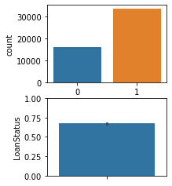

```python
fig = plt.figure()

ax1 = fig.add_subplot(221)
sns.countplot(df_ls["LoanStatus"])

ax2 = fig.add_subplot(223)
sns.barplot(y=df_ls["LoanStatus"]).set_ylim([0,1])
```

Above plot show that number of borrowers who completed their loans are much higher than defaulters.

## Monthly Loan Payment Frequency Destribution:

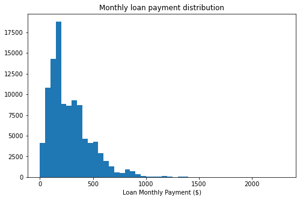

```python
# Monthly loan payment distribution
binsize = 50
bins = np.arange(0,df['MonthlyLoanPayment'].max()+binsize, binsize)

plt.figure(figsize=[8, 5])
plt.hist(data = df, x = 'MonthlyLoanPayment', bins = bins)
plt.xlabel('Loan Monthly Payment ($)')
plt.title('Monthly loan payment distribution')
plt.show()
```

Destribution is skewed towards right direcion and higheest peak was recorded at below $500 of monthly loan payment while there has been a downfall beyond $500 of loan payment.

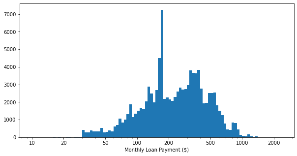

```python
# Using log-scale
log_binsize = 0.025
bins = 10 ** np.arange(1, np.log10(df['MonthlyLoanPayment'].max())+log_binsize, log_binsize)

plt.figure(figsize=[10, 5])
plt.hist(data = df, x = 'MonthlyLoanPayment', bins = bins)
plt.xscale('log')
plt.xticks([10, 20, 50, 100, 200, 500, 1e3, 2e3], ['10', '20','50', '100', '200', '500', '1000', '2000'])
plt.xlabel('Monthly Loan Payment ($)')
plt.show()
```

## Lender Yield Destribution:

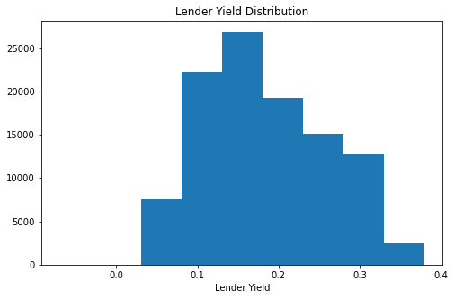

```python
#Lender Yield Distribution
binsize = 0.05
bins = np.arange(-.07, df['LenderYield'].max()+binsize, binsize)

plt.figure(figsize=[8, 5])
plt.hist(data = df, x = 'LenderYield', bins = bins)
plt.xlabel('Lender Yield')
plt.title('Lender Yield Distribution')

plt.show()
```

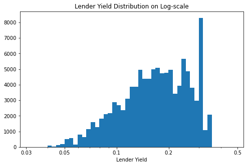

```python
#Lender Yield Distribution with log scale and truncation
log_binsize = 0.025
bins = 10 ** np.arange(-1.5, -0.3, log_binsize)

plt.figure(figsize=[8, 5])
plt.hist(data = df, x = 'LenderYield', bins = bins)
plt.xscale('log')
plt.xticks([3e-2, 5e-2, 1e-1, 2e-1, 5e-1], ['0.03', '0.05', '0.1', '0.2', '0.5'])
plt.xlabel('Lender Yield')
plt.title('Lender Yield Distribution on Log-scale')

plt.show()
```

```python
df.info()
```

```
<class 'pandas.core.frame.DataFrame'>
Int64Index: 106290 entries, 0 to 113936
Data columns (total 80 columns):
 #   Column                               Non-Null Count   Dtype
---  ------                               --------------   -----
 0   ListingCreationDate                  106290 non-null  datetime64[ns]
 1   CreditGrade                          21325 non-null   object
 2   Term                                 106290 non-null  int64
 3   LoanStatus                           106290 non-null  object
 4   ClosedDate                           47452 non-null   datetime64[ns]
 5   BorrowerAPR                          106290 non-null  float64
 6   BorrowerRate                         106290 non-null  float64
 7   LenderYield                          106290 non-null  float64
 8   EstimatedEffectiveYield              106290 non-null  float64
 9   EstimatedLoss                        106290 non-null  float64
```

[output cut: 72 more lines]

```python
df["ListingYear"] = df['ListingCreationDate'].map(lambda x: x.year)
```

## Frequency destribution of Listing Creation Year:

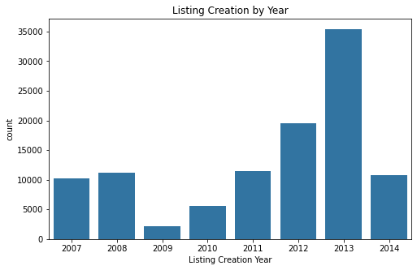

```python
# Listing Creation  by Year
plt.figure(figsize=[8, 5])
sns.countplot(data=df,x=df['ListingYear'],color=base_color)
plt.title('Listing Creation by Year')
plt.xlabel('Listing Creation Year');
```

Highest Listing was created in year 2013 followed by year 2012.

## Occupation Vs Loan Original Amount :

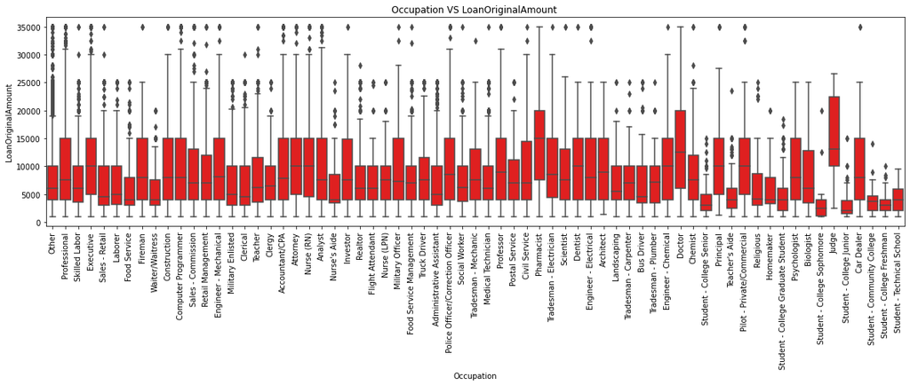

```python
plt.figure(figsize=(20,5))
sns.boxplot(
    data=df,
    x='Occupation',
    y='LoanOriginalAmount',
    color='red')
plt.xticks(rotation = 90)
plt.title('Occupation VS LoanOriginalAmount ')
plt.xlabel('Occupation')
plt.ylabel('LoanOriginalAmount');
```

## Loan Status And Loan original Amount:

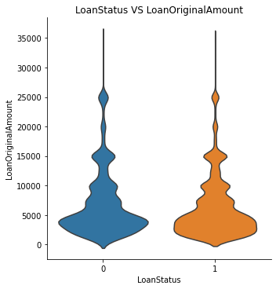

```python
g = sns.catplot(x="LoanStatus", y="LoanOriginalAmount", kind="violin", inner=None, data=df_ls)
#sns.swarmplot(x="LoanStatus", y="LoanOriginalAmount", color="k", size=3, data=df_ls, ax=g.ax)
plt.title('LoanStatus VS LoanOriginalAmount')
plt.xlabel('LoanStatus')
plt.ylabel('LoanOriginalAmount');
```

```python
df.Term.value_counts()
```

```
36    80133
60    24543
12     1614
Name: Term, dtype: int64
```

## LoanStatus and Term Destribution:

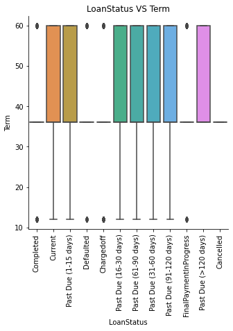

```python
sns.catplot(x="LoanStatus", y="Term", kind="box", data=df)
plt.xticks(rotation = 90)
plt.title('LoanStatus VS Term')
plt.xlabel('LoanStatus')
plt.ylabel('Term');
```